# Optimizing sampling design for landscape genomics: Paramaterizing correlations between environmental layers

Anusha P. Bishop, Drew E. Terasaki Hart, Ian J. Wang

To determine how to set the levels of correlation between our environmental layers we created distributions of correlations between temperature and precipitation globally. We downloaded global average temperature and precipitation data for 1970-2000 at a resolution of 2.5 minutes of a degree from WorldClim using the “geodata” package (Hijmans et al., 2023). This data is monthly, so we took the mean across all months to get one raster layer representing temperature and one representing precipitation. To generate our distributions we randomly sampled one thousand 100 by 100 cell sections of each raster and calculated the correlation between temperature and precipitation within those sections. We took the absolute value of the correlations since for our simulations only the magnitude matters, not the direction. For our simulations we chose 0.30 for our low level and 0.60 for our high level which corresponded to approximately the first and second quartile (i.e., the median) of the distribution of correlations. We didn’t select the third quartile value of 0.84 because when a pair of environmental variables has a correlation greater than 0.70 one of them is usually dropped in landscape genomic analyses. Therefore, we wanted our high level of correlation to still be below the threshold of being too correlated to be disentangled. The code used to create these distributions can be found in the same notebook used to generate this file [here](https://github.com/AnushaPB/LandGenSamp/blob/main/p1_gnxsims/MNLM/File_S2.Rmd).

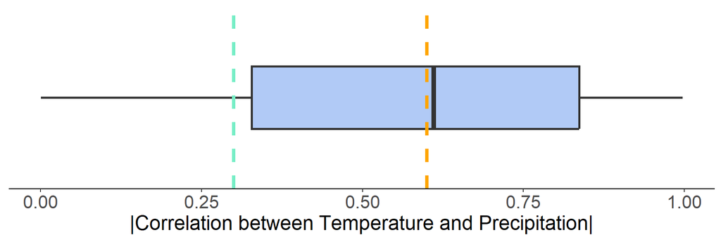

**Figure 1.** Boxplot of the absolute value of correlations between global temperature and precipitation. Green and orange dashed lines represent the low and high levels of correlation used in our simulation.

### References:

1. Fick, S.E. and R.J. Hijmans, 2017. WorldClim 2: new 1km spatial resolution climate surfaces for global land areas. International Journal of Climatology 37 (12): 4302-4315.
2. Hijmans RJ, Barbosa M, Ghosh A, Mandel A (2023). geodata: Download Geographic Data. R package version 0.5-8, https://CRAN.R-project.org/package=geodata.